# Estudios de Informática, Multimedia y Telecomunicaciones

# Mineria de dades: PRA2 - Projecte de mineria de dades

Autor: Gerard Pérez Vancells

Desembre 2022

# 1 Enunciat

Com a continuació de la primera activitat, a la pràctica PRA2 utilitzareu el conjunt de dades preparat a la PRA1 per tal d’extreure coneixement i donar resposta a la pregunta o problema definit, aplicant els algorismes de clustering, regressió o classificació necessaris per a ells, avaluant l’exercici dels diferents models i seleccionant el més adequat al problema en qüestió.

Partim de l’estudi iniciat a la Pràctica 1, on abordem un cas real de mineria de dades on hem posat en joc tots els conceptes treballats a l’assignatura. Recordeu que cal **treballar tot el cicle de vida del projecte** com una sola peça, des de l’objectiu del projecte fins a la implementació del coneixement trobat, passant per la preparació, neteja de les dades, exploració de les dades i procedim a **aplicar els models analítics vistos a l’assignatura** sobre el joc de dades previ seleccionat i preparat per a aquest fi, la seva interpretació i avaluació.

En aquesta **Pràctica 2** s’aconsella adjuntar el codi de la part de preparació prèvia, exemple (neteja, discretització, normalització, PCA/SVD etc.), o si no, carregar només les dades prèviament preparades.

**En tots els punts successius** es demana a l’estudiant:

- **aplicar el model analític** corresponent.
- **analitzar** correctament el problema.
- **detallar de manera exhaustiva** ressaltant el perquè i com s’ha realitzat, incloent-hi elements visuals.
- **explicació** dels resultats obtinguts.
- **realitzar les comparatives** oportunes amb les seues conclusions.

Per a totes les PRA és necessari documentar a cada apartat de l’exercici pràctic que s’ha fet, per què s’ha fet i com s’ha fet. Així mateix, totes les decisions i conclusions hauran de ser presentades de forma raonada i clara, **contextualitzant els resultats**, és a dir, especificant tots i cadascun dels passos que s’hagin dut a terme per a resoldre’ls.

D’aquesta manera es demana a l’estudiant que completi els passos següents:

1. Aplicar un model **no supervisat** i basat en el concepte de distància, sobre el joc de dades, interpretant els resultats obtinguts.
2. Aplicar de nou el model anterior, però usant una **mètrica de distància diferent** i comparar els resultats.
3. S’apliquen els algorismes **DBSCAN i OPTICS**, es proven amb diferents valors de `eps` i s’interpreten i comparen els resultats amb els mètodes anteriors.
4. Aplicar un model de generació de regles a partir de **arbres de decisió**, ajustant les diferents opcions de creació com sense i amb opcions de poda o boosting, interpretar i comparar els resultats.
5. Aplicar un **model supervisat** diferent de l’anterior, **a triar dels vistos al material docent**. Interpretar i comparar el resultat amb el model generat anteriorment.
6. Identificar eventuals **limitacions** del dataset seleccionat i **analitzar els riscos** per al cas d’ús.
7. A cada fase del modelatge, interpretar els **resultats** obtinguts per tal de comentar les limitacions de l’algorisme utilitzat, realitzar la comparativa pertinent i/o indicar els problemes trobats i com resoldre’ls.

En aquesta pràctica s’utilitzaran els models vistos durant aquest semestre. De manera totalment voluntària és possible afegir, a més dels models estudiats, altres models que no s’han vist als materials disponibles a l’aula.

# 2 Criteris d’avaluació

- Exercici 1 - 20%
  - Es genera un model no supervisat.
  - S’analitzen, mostren i comenten les mesures de qualitat del model generat.
  - S’interpreten els resultats i comenten les conclusions.
- Exercici 2 - 10%
  - Es genera de nou el model no supervisat anterior, però usant una mètrica de distància diferent.
  - Es mostren i comenten les mesures de qualitat del model generat.
  - Addicionalment es comparen els dos models no supervisats amb mètriques de distància diferents.
  - S’interpreten els resultats i comenten les conclusions.
- Exercici 3 - 10%
  - S’apliquen els algorismes DBSCAN i OPTICS de forma correcta.
  - Es proven, descriuen i interpreten els resultats amb diferents valors d’eps.
  - S’obté una mesura de com és de bo l’agrupament.
  - S’interpreten i es comparen els resultats obtinguts dels models anteriors i DBSCAN.
  - Es comenten les conclusions.
  - Identifica quines possibles limitacions tenen les dades que has seleccionat per obtenir conclusions amb els models utilitzats (no supervisats).
- Exercici 4 - 20%
  - Es generen regles i es comenten i interpreten les més significatives.
  - Extraiem les regles del model en format text i gràfic.
  - Addicionalment, es genera matriu de confusió per mesurar la capacitat predictiva de l’algorisme.
  - Es comparen i interpreten els resultats (sense i amb opcions de poda o boosting), explicant els avantatges i els inconvenients del model generat respecte a un altre mètode de construcció.
  - S’avalua la taxa d’error a cada nivell d’arbre, l’eficiència en classificació (a les fases de training, validació i test) i la comprensibilitat.
  - S’interpreten i es comenten les conclusions.
- Exercici 5 - 10%
  - Prova amb una variació o un altre enfocament algorítmic amb els algorismes vistos a l’assignatura.
  - Es detalla, comenta i avalua la qualitat de classificació.
  - Es comparen i comenten els resultats de manera exhaustiva amb el mètode de construcció anterior.
  - Identifica i comenta quines possibles limitacions tenen les dades que has seleccionat per obtenir conclusions amb els models utilitzats (supervisat).
- Exercici 6 - 10%
  - S’identifiquen possibles riscos de l’ús del model (mínim 300 paraules).
- Exercici 7 - 10%
  - Què he après en aquesta pràctica, quines limitacions he observat i com ho he solucionat (mínim 300 paraules).
- Consideració general - 10%
  - Es presenta el codi i és fàcilment reproduïble.
  - Es detalla cada pregunta de manera correcta, mostrant-ne el codi, comentant com s’ha fet i perquè s’ha fet, comparant els resultats i/o indicant altres alternatives al problema indicat.
  - Es mostren les conclusions a cada apartat
  - S’indiquen eventuals citacions bibliogràfiques, fonts internes/externes i materials de recerca.

# 3 Recursos de programació

- Incloem en aquest apartat una llista de recursos de programació per a mineria de dades on podreu trobar exemples, idees i inspiració:
  - [Material addicional del llibre: Mineria de dades Models i Algorismes](http://oer.uoc.edu/libromd/)
  - [Espai de recursos UOC per a ciència de dades](http://datascience.recursos.uoc.edu/es/)
  - [Cercador de codi R](https://rseek.org/)
  - [Col·lecció de cheatsheets en R](https://rstudio.com/resources/cheatsheets/)

# 4 Format i data de lliurament

El format de lliurament és: **username_estudiante-PRA2** *.Rmd* i l’**output generat** en un d’aquests formats *html/doc/docx/odt/pdf*.

S’ha de lliurar la PRA a la bústia de lliuraments de l’aula en format comprimit que inclou els fitxers: - executable - output - el dataset seleccionat o si no n’hi ha (en cas que sigui un fitxer molt pesat), indicar la ruta per a baixar-la a l’executable.

# 5 Nota: Propietat intel·lectual

> Sovint és inevitable, en produir una obra multimèdia, fer ús de recursos creats per terceres persones. És per tant comprensible fer-ho en el marc d’una pràctica dels estudis d’Informàtica, Multimèdia i Telecomunicació de la UOC, sempre que això es documenti clarament i no suposi plagi en la pràctica.

> Per tant, en presentar una pràctica que faci ús de recursos aliens, s’ha de presentar juntament amb ella un document en el que es detallin tots ells, especificant el nom de cada recurs, el seu autor, el lloc on es va obtenir i el seu estatus legal: si l’obra aquesta protegida pel copyright o s’acull a alguna altra llicència d’ús (Creative Commons, llicència GNU, GPL …). L’estudiant haurà d’assegurar-se que la llicència no impedeix específicament el seu ús en el marc de la pràctica. En cas de no trobar la informació corresponent haurà d’assumir que l’obra aquesta protegida per copyright.

> Haureu, a més, adjuntar els fitxers originals quan les obres utilitzades siguin digitals, i el seu codi font si correspon.

# 6 RESPOSTES

Preparació de les dadesde la PR1:

### 6.0.1 **Anàlisi de les dades**

Instal·lem llibraries necessàries.

```r
if (!require('ggplot2')) install.packages('ggplot2'); library('ggplot2')
if (!require('dplyr')) install.packages('dplyr'); library('dplyr')
```

Carreguem l’arxiu a Rstudio amb el nom de cada columna.

```r
abaloneSet <- read.csv('abalone.data',stringsAsFactors = FALSE, header= FALSE)
names(abaloneSet) <- c("Sex", "Length", "Diameter", "Height", "WholeWeight", "ShuckedWeight", "VisceraWeight", "ShellWeight", "Rings")
head(abaloneSet)
```

```
##   Sex Length Diameter Height WholeWeight ShuckedWeight VisceraWeight
## 1   M  0.455    0.365  0.095      0.5140        0.2245        0.1010
## 2   M  0.350    0.265  0.090      0.2255        0.0995        0.0485
## 3   F  0.530    0.420  0.135      0.6770        0.2565        0.1415
## 4   M  0.440    0.365  0.125      0.5160        0.2155        0.1140
## 5   I  0.330    0.255  0.080      0.2050        0.0895        0.0395
## 6   I  0.425    0.300  0.095      0.3515        0.1410        0.0775
##   ShellWeight Rings
## 1       0.150    15
## 2       0.070     7
## 3       0.210     9
## 4       0.155    10
## 5       0.055     7
## 6       0.120     8
```

Comprobem si hi ha algunvalor nul o buit.

```r
colMeans(is.na(abaloneSet))
```

```
##           Sex        Length      Diameter        Height   WholeWeight
##             0             0             0             0             0
## ShuckedWeight VisceraWeight   ShellWeight         Rings
##             0             0             0             0
```

```r
colMeans(abaloneSet=="")
```

```
##           Sex        Length      Diameter        Height   WholeWeight
##             0             0             0             0             0
## ShuckedWeight VisceraWeight   ShellWeight         Rings
##             0             0             0             0
```

Podem corroborar que no hi ha registres amb dades null o buides.

Consultem les dades del Set.

```r
summary(abaloneSet)
```

```
##      Sex                Length         Diameter          Height
##  Length:4177        Min.   :0.075   Min.   :0.0550   Min.   :0.0000
##  Class :character   1st Qu.:0.450   1st Qu.:0.3500   1st Qu.:0.1150
##  Mode  :character   Median :0.545   Median :0.4250   Median :0.1400
##                     Mean   :0.524   Mean   :0.4079   Mean   :0.1395
##                     3rd Qu.:0.615   3rd Qu.:0.4800   3rd Qu.:0.1650
##                     Max.   :0.815   Max.   :0.6500   Max.   :1.1300
##   WholeWeight     ShuckedWeight    VisceraWeight     ShellWeight
##  Min.   :0.0020   Min.   :0.0010   Min.   :0.0005   Min.   :0.0015
##  1st Qu.:0.4415   1st Qu.:0.1860   1st Qu.:0.0935   1st Qu.:0.1300
##  Median :0.7995   Median :0.3360   Median :0.1710   Median :0.2340
##  Mean   :0.8287   Mean   :0.3594   Mean   :0.1806   Mean   :0.2388
##  3rd Qu.:1.1530   3rd Qu.:0.5020   3rd Qu.:0.2530   3rd Qu.:0.3290
##  Max.   :2.8255   Max.   :1.4880   Max.   :0.7600   Max.   :1.0050
##      Rings
##  Min.   : 1.000
##  1st Qu.: 8.000
##  Median : 9.000
##  Mean   : 9.934
##  3rd Qu.:11.000
##  Max.   :29.000
```

Visualitzem les gràfiques de cada columna per identificar algun valor atípic.

```r
if (!require('survival')) install.packages('survival'); library('survival')
if (!require('packHV')) install.packages('packHV'); library('packHV')
```

Imprimim l’histograma de les columnes numèriques :

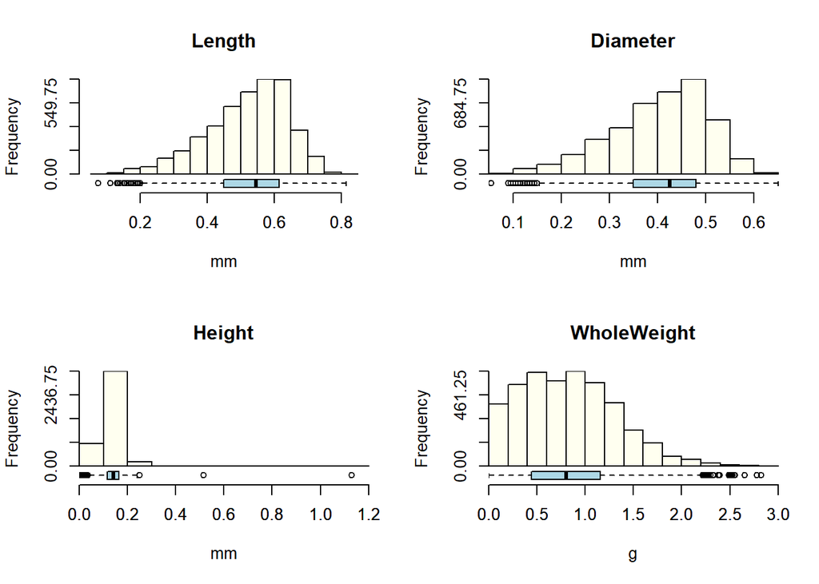

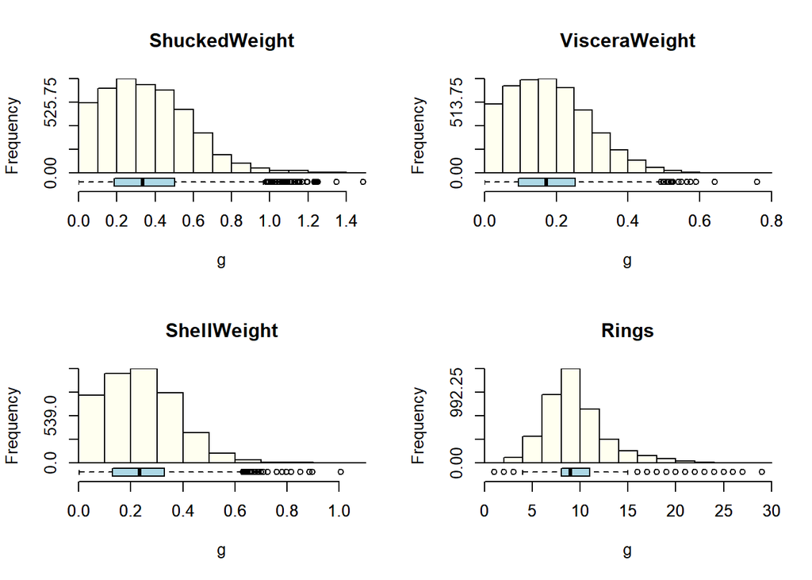

```r
par(mfrow=c(2,2))
for (i in 2:9){
hist_boxplot(abaloneSet[,i],xlab=ifelse(i<5,"mm","g"),col="ivory",main=names(abaloneSet[i]))
}
```

Veiem outliers a ShellWeight, ShuckeWeight, VisceraWeight i sobretot a Height.

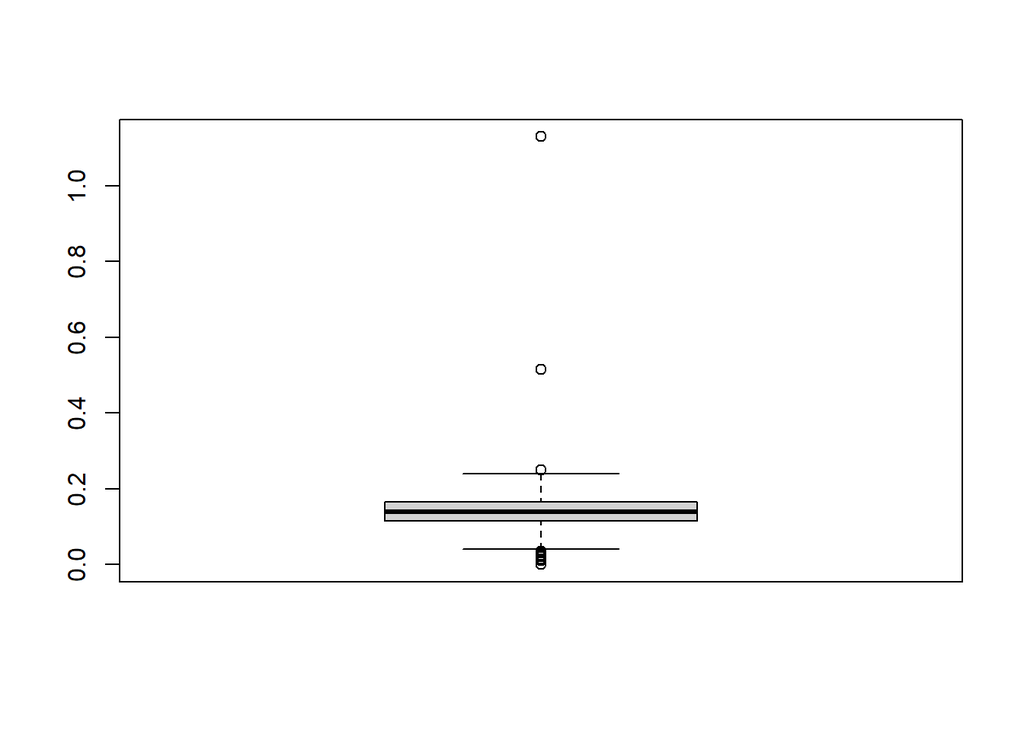

```r
heightBox<-boxplot(abaloneSet$Height)
```

Veiem que són únicament dos registres que tenen un valor molt alt( superior a 0,4) en comparació a la resta, els eliminem.

```r
abaloneSet<-abaloneSet[abaloneSet$Height<0.4,]
```

Comprobem:

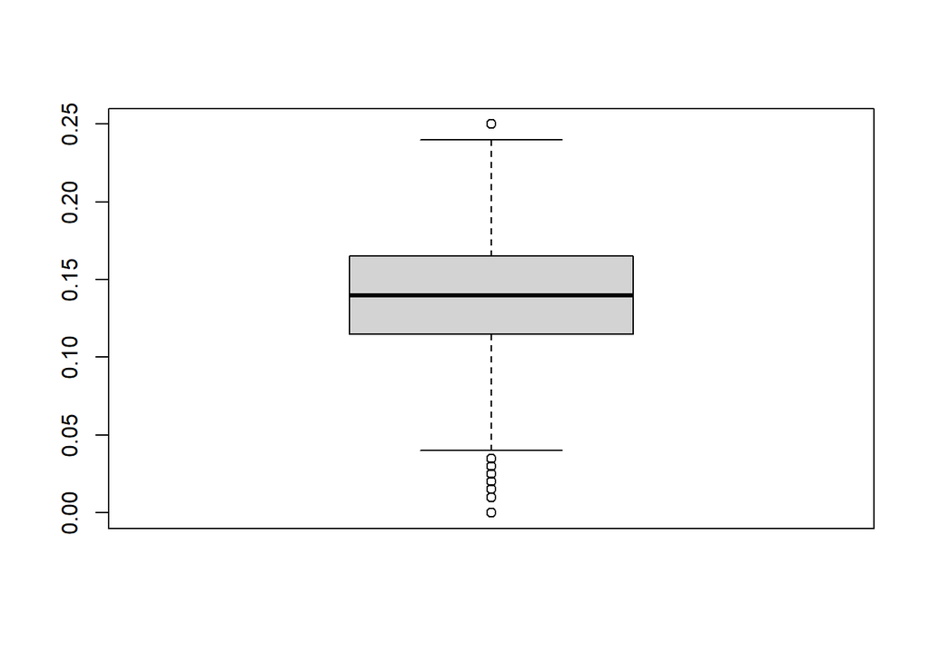

```r
heightBox<-boxplot(abaloneSet$Height)
```

Repetim amb les altres columnes:

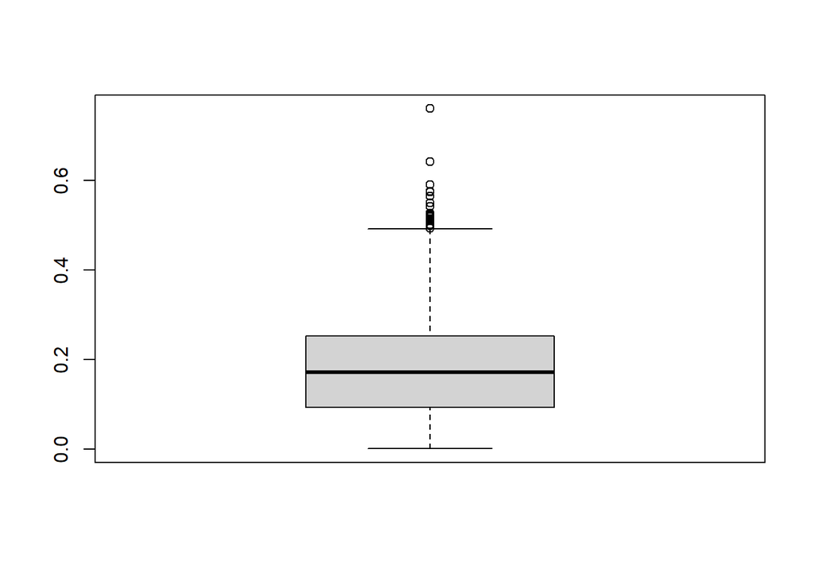

```r
heightBox1<-boxplot(abaloneSet$VisceraWeight)
```

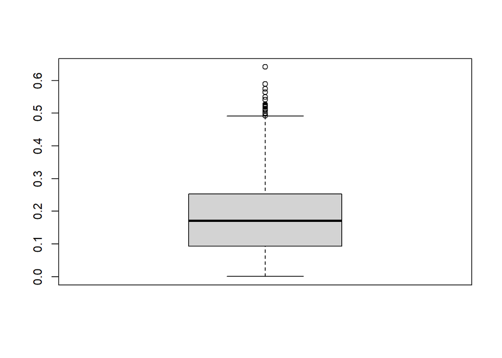

```r
abaloneSet<-abaloneSet[abaloneSet$VisceraWeight<0.7,]
heightBox1<-boxplot(abaloneSet$VisceraWeight)
```

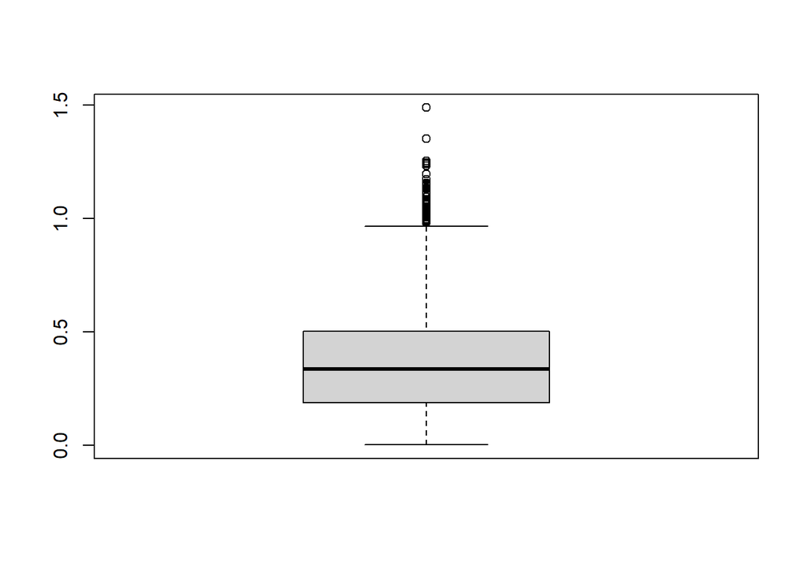

```r
heightBox1<-boxplot(abaloneSet$ShuckedWeight)
```

No és tan outlier, el podem deixar.

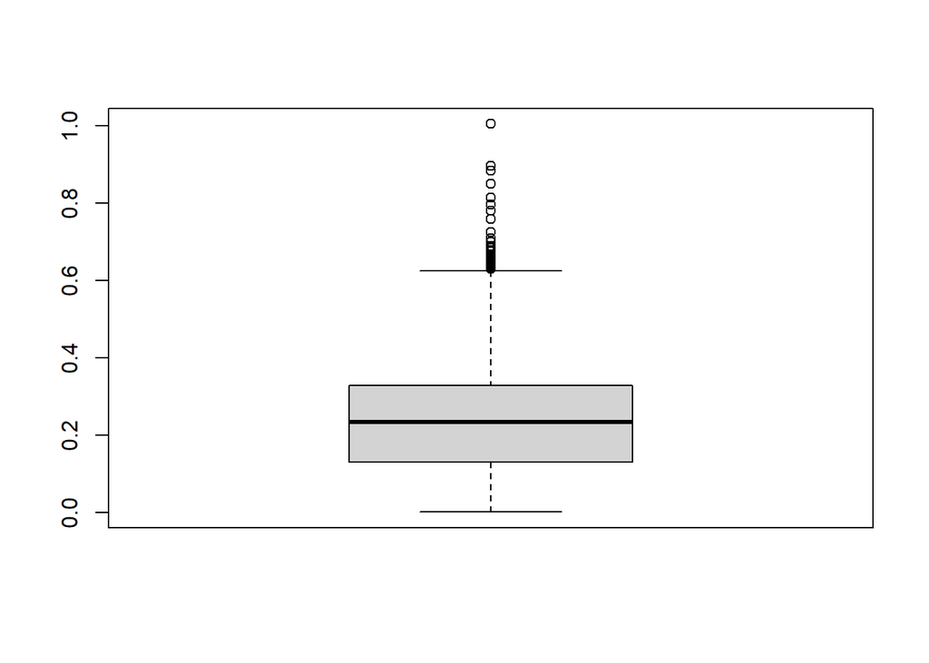

```r
heightBox1<-boxplot(abaloneSet$ShellWeight)
```

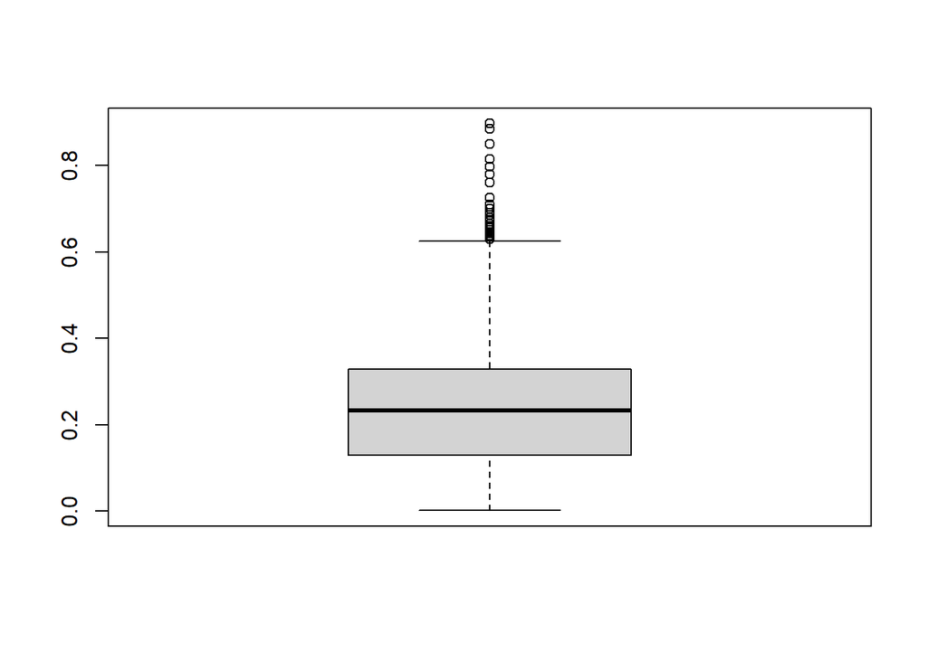

```r
abaloneSet<-abaloneSet[abaloneSet$ShellWeight<0.9,]
heightBox1<-boxplot(abaloneSet$ShellWeight)
```

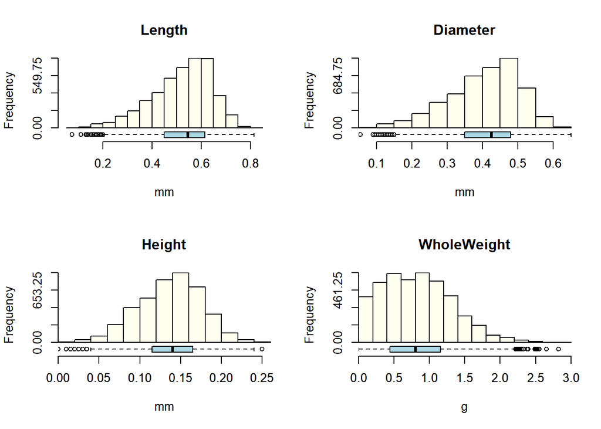

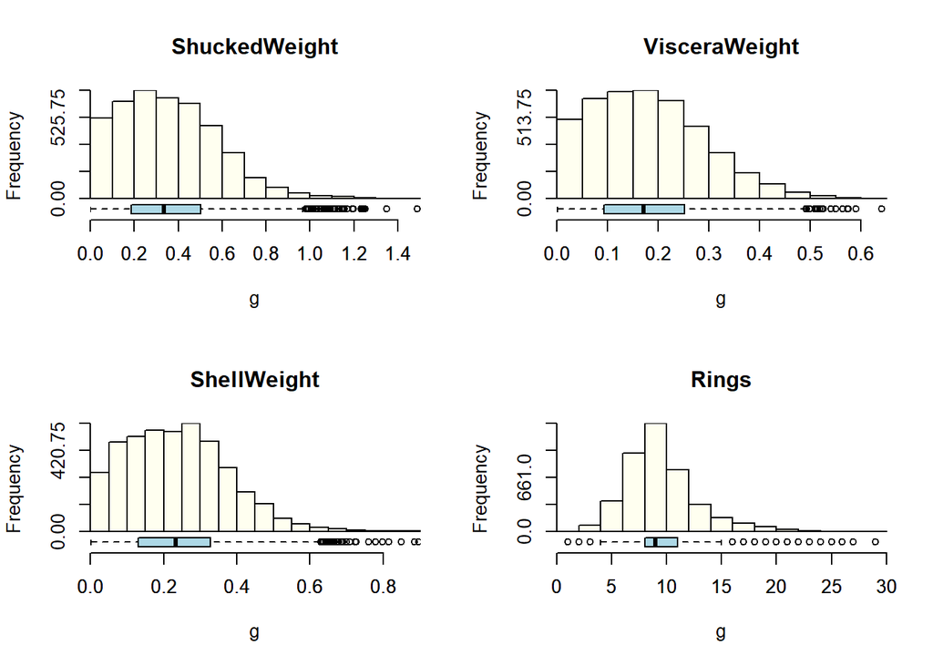

```r
par(mfrow=c(2,2))
for (i in 2:9){
hist_boxplot(abaloneSet[,i],xlab=ifelse(i<5,"mm","g"),col="ivory",main=names(abaloneSet[i]))
}
```

Podem veure que els histogrames Length i Diameter tenen una forma semblant i podria ser un indici de correlació. També es pot veure una forma semblant amb WholeWeight, ShuckedWeight, VisceraWeight i ShellWeight.

Seguim amb l’anàlisi visualitzant els diferents atributs en funció del sexe:

Visualitzem les dades en violí:

```r
if (!require('gridExtra')) install.packages('gridExtra'); library('gridExtra')
if (!require('grid')) install.packages('grid'); library('grid')
```

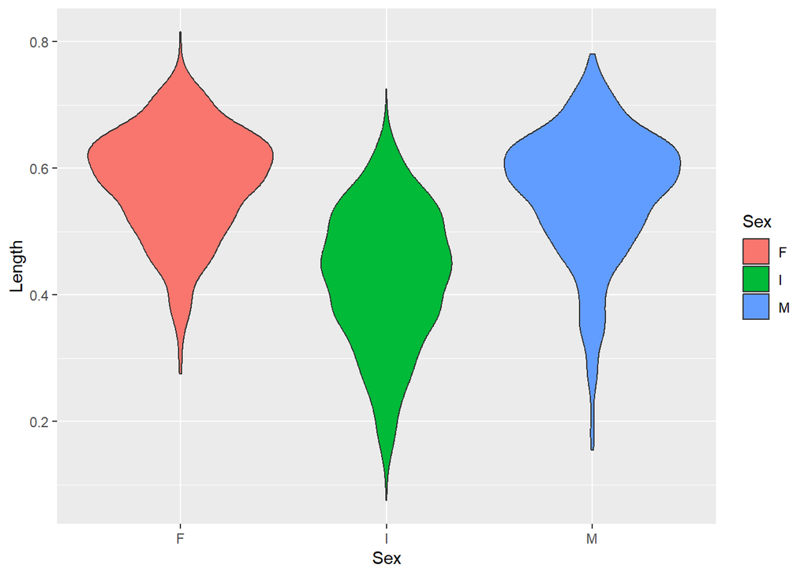

```r
ggplot(abaloneSet, aes(x=Sex, y=Length, fill=Sex)) + geom_violin()
```

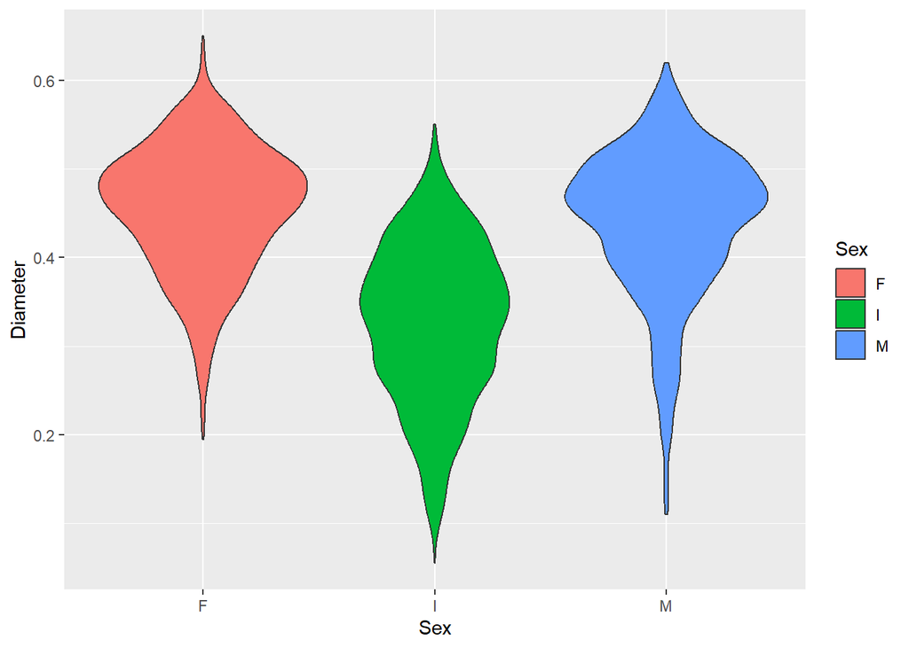

```r
ggplot(abaloneSet, aes(x=Sex, y=Diameter, fill=Sex)) + geom_violin()
```

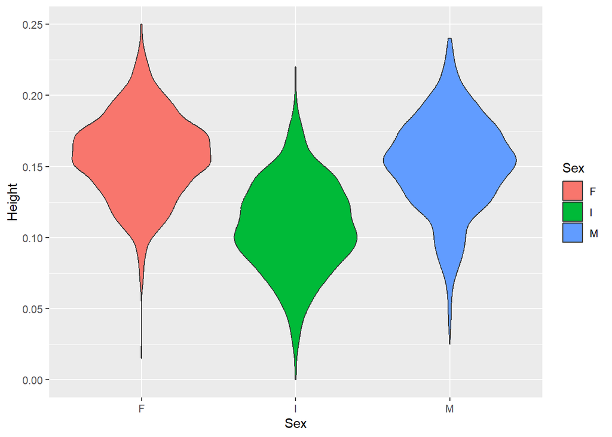

```r
ggplot(abaloneSet, aes(x=Sex, y=Height, fill=Sex)) + geom_violin()
```

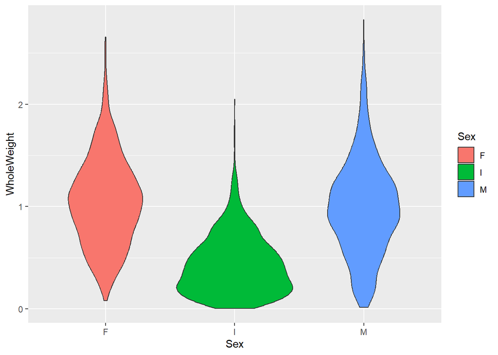

```r
ggplot(abaloneSet, aes(x=Sex, y=WholeWeight, fill=Sex)) + geom_violin()
```

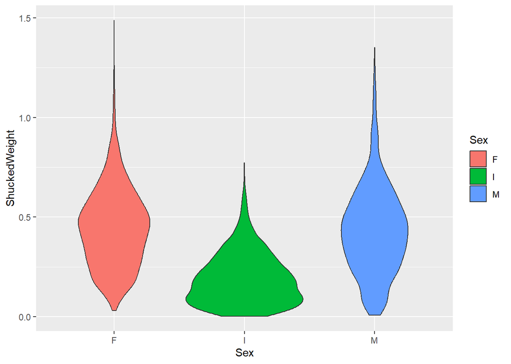

```r
ggplot(abaloneSet, aes(x=Sex, y=ShuckedWeight, fill=Sex)) + geom_violin()
```

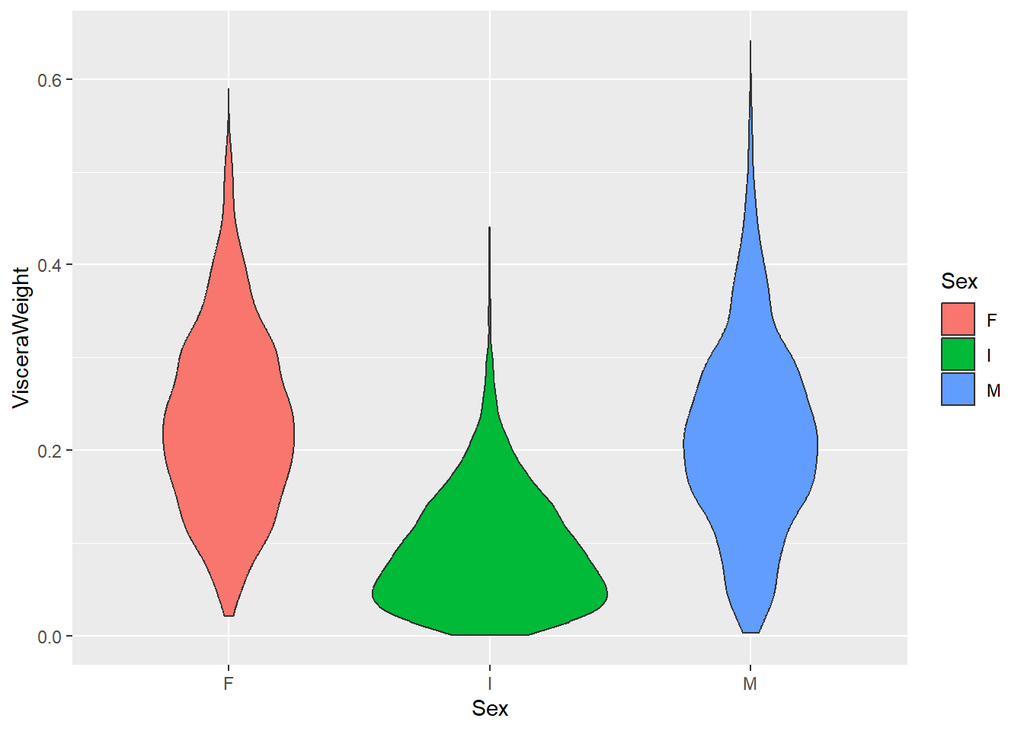

```r
ggplot(abaloneSet, aes(x=Sex, y=VisceraWeight, fill=Sex)) + geom_violin()
```

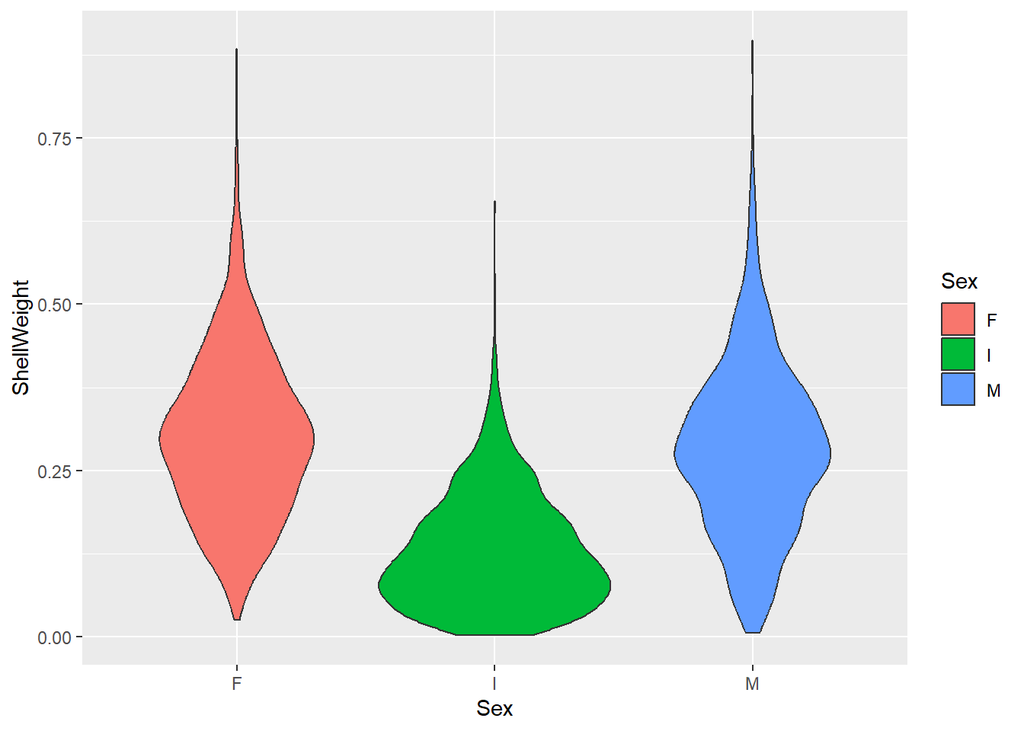

```r
ggplot(abaloneSet, aes(x=Sex, y=ShellWeight, fill=Sex)) + geom_violin()
```

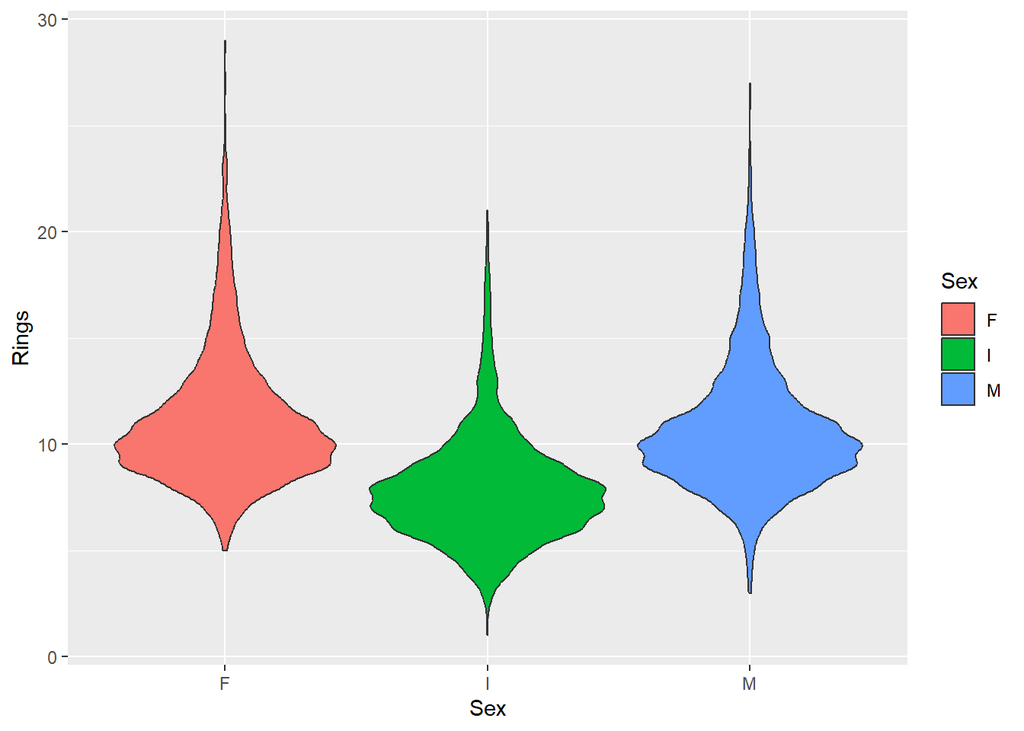

```r
ggplot(abaloneSet, aes(x=Sex, y=Rings, fill=Sex)) + geom_violin()
```

Podem veure com els grups M i F son molt semblants i que el grup infantil és l’únic que difereix dels demès.

```r
if (!require('GGally')) install.packages('GGally'); library('GGally')
```

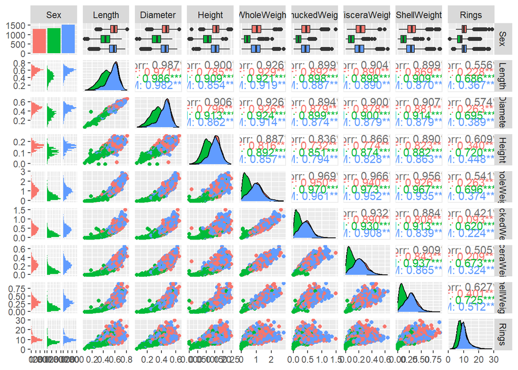

```r
abaloneSetTmp <-abaloneSet
abaloneSetTmp$Sex <- factor(abaloneSetTmp$Sex, labels = c("F","I", "M"))
ggpairs(abaloneSetTmp, aes(colour = Sex))
```

Podem tornar a veure com les diferències principals es produeixen entre el sexe infantil (color verd) i sexe masculí o femení (color blau i taronja).

Si ens fixem en la correlació entre les columnes:

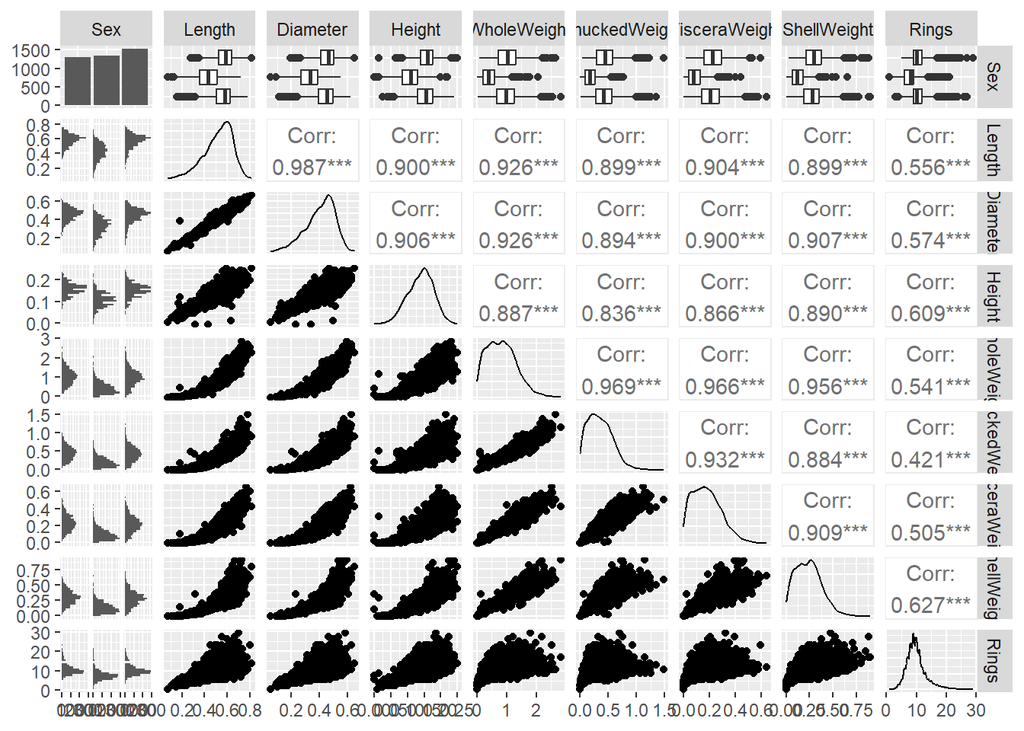

```r
ggpairs(abaloneSet)
```

Observem vàries correlacions altes: entre diàmetre i longitud (0,987), ShuckedWeight i WholeWeight (0,969) i VisceraWeight i WholeWeight(0,966). En general hi ha una correlació alta entre totes les columnes menys amb la de Rings.

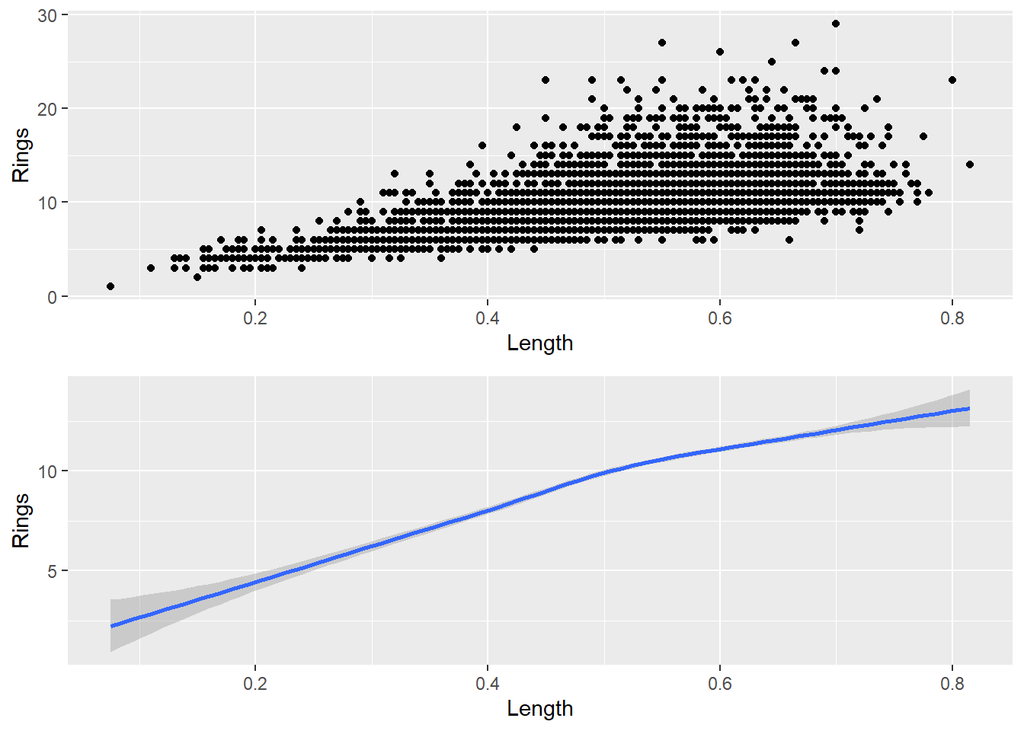

```r
grid.arrange(
qplot(Length, Rings, data=abaloneSet),
qplot(Length, Rings, data=abaloneSet, geom = c("smooth")))
```

Si ho separem per sexe:

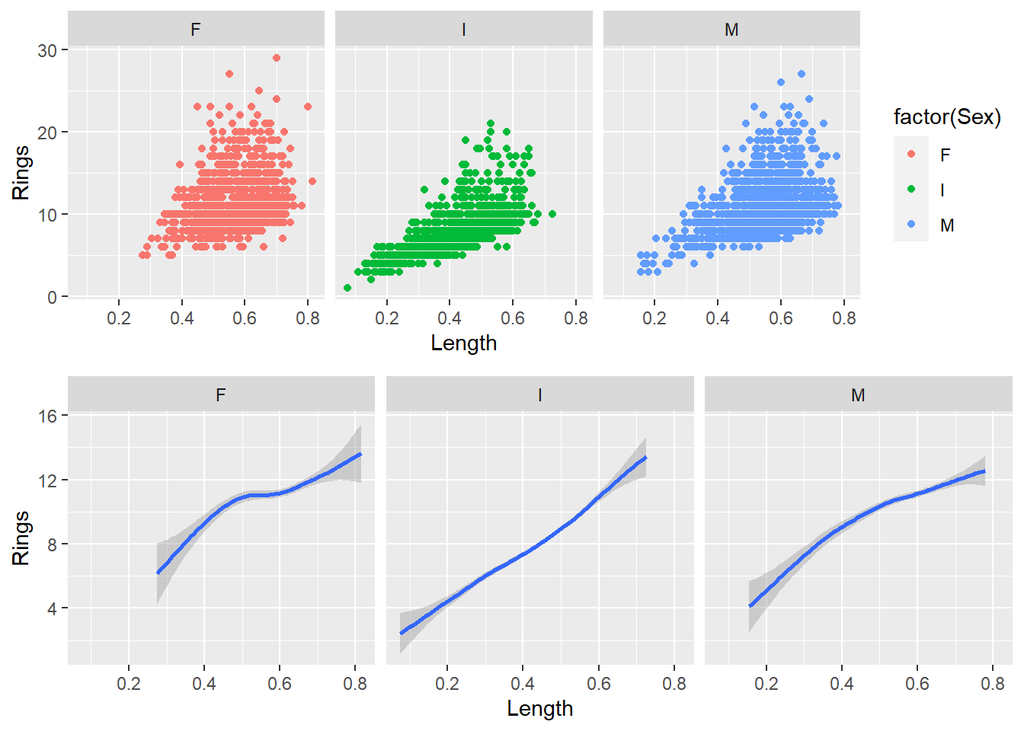

```r
grid.arrange(
qplot(Length, Rings, data=abaloneSet, facets = .~factor(Sex), color = factor(Sex)),
qplot(Length, Rings, data=abaloneSet, facets = .~factor(Sex),geom = c("smooth")))
```

Podem veure com hi ha certa correlació entre longitud i anells en el cas del grup I ( sexe infantil). No obstant això, no ens serveix gaire si pels grups de sexe M i F no hi ha una correlació semblant.

Passem a l’anàlisi PCA i reduir la dimensionalitat del conjunt de dades.

```r
if (!require('FactoMineR')) install.packages('FactoMineR'); library('FactoMineR')
if (!require('factoextra')) install.packages('factoextra'); library('factoextra')
```

Passem a analitzar quines columnes podem eliminar del conjunt d’atributs. L’atribut Rings i Sex no el tindrem en compte ja que són claus per l’estudi.

```r
abalonePCA<-PCA(X = abaloneSet[,-c(1,9)], scale.unit = TRUE, ncp = 7, graph = FALSE)
summary(abalonePCA)
```

```
##
## Call:
## PCA(X = abaloneSet[, -c(1, 9)], scale.unit = TRUE, ncp = 7, graph = FALSE)
##
##
## Eigenvalues
##                        Dim.1   Dim.2   Dim.3   Dim.4   Dim.5   Dim.6   Dim.7
## Variance               6.471   0.214   0.138   0.093   0.064   0.013   0.007
## % of var.             92.441   3.061   1.977   1.327   0.917   0.182   0.096
## Cumulative % of var.  92.441  95.502  97.479  98.806  99.723  99.904 100.000
##
## Individuals (the 10 first)
##                   Dist    Dim.1    ctr   cos2    Dim.2    ctr   cos2    Dim.3
## 1             |  1.885 | -1.796  0.012  0.908 | -0.190  0.004  0.010 | -0.393
## 2             |  3.412 | -3.401  0.043  0.994 | -0.221  0.005  0.004 |  0.153
## 3             |  0.713 | -0.478  0.001  0.450 |  0.456  0.023  0.409 | -0.198
## 4             |  1.539 | -1.512  0.008  0.965 |  0.187  0.004  0.015 |  0.080
## 5             |  3.725 | -3.703  0.051  0.988 | -0.385  0.017  0.011 |  0.101
## 6             |  2.592 | -2.574  0.025  0.986 | -0.115  0.001  0.002 | -0.062
## 7             |  0.982 |  0.018  0.000  0.000 |  0.618  0.043  0.395 |  0.493
## 8             |  0.634 | -0.208  0.000  0.107 |  0.187  0.004  0.087 | -0.235
## 9             |  1.397 | -1.364  0.007  0.952 |  0.298  0.010  0.046 | -0.056
## 10            |  0.843 |  0.408  0.001  0.234 |  0.475  0.025  0.317 |  0.219
##                  ctr   cos2
## 1              0.027  0.044 |
## 2              0.004  0.002 |
## 3              0.007  0.077 |
## 4              0.001  0.003 |
## 5              0.002  0.001 |
## 6              0.001  0.001 |
## 7              0.042  0.252 |
## 8              0.010  0.137 |
## 9              0.001  0.002 |
## 10             0.008  0.068 |
##
## Variables
##                  Dim.1    ctr   cos2    Dim.2    ctr   cos2    Dim.3    ctr
## Length        |  0.968 14.480  0.937 |  0.141  9.291  0.020 | -0.187 25.247
## Diameter      |  0.969 14.505  0.939 |  0.157 11.523  0.025 | -0.164 19.403
## Height        |  0.933 13.462  0.871 |  0.261 31.750  0.068 |  0.178 22.895
## WholeWeight   |  0.986 15.010  0.971 | -0.145  9.845  0.021 |  0.043  1.325
## ShuckedWeight |  0.953 14.044  0.909 | -0.231 24.928  0.053 | -0.081  4.765
## VisceraWeight |  0.963 14.322  0.927 | -0.164 12.606  0.027 |  0.029  0.608
## ShellWeight   |  0.958 14.178  0.917 | -0.011  0.057  0.000 |  0.189 25.757
##                 cos2
## Length         0.035 |
## Diameter       0.027 |
## Height         0.032 |
## WholeWeight    0.002 |
## ShuckedWeight  0.007 |
## VisceraWeight  0.001 |
## ShellWeight    0.036 |
```

Veiem que amb una dimensió cubriríem el 92,441% de la variabilitati amb dues dimensions un 95,502%.

Tot i que ja aparegui en la taula anterior, podem visualitzar en forma de gràfic el percentatge de contribució en cada dimensió.

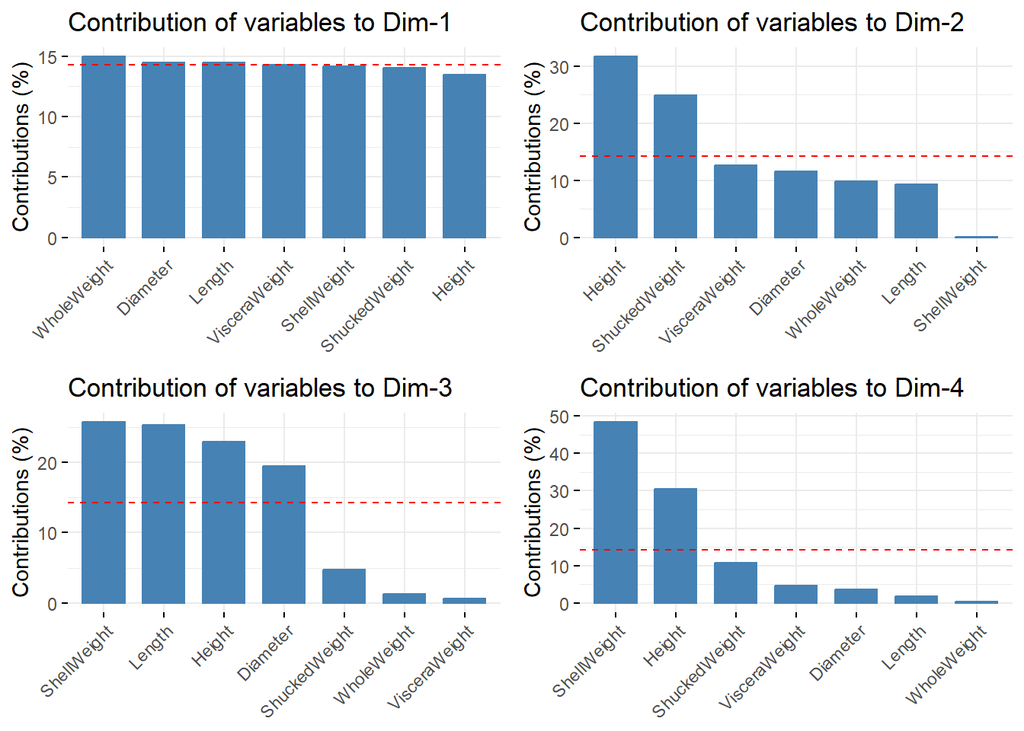

```r
grid.arrange(
fviz_contrib(abalonePCA, choice = "var", axes = 1),
fviz_contrib(abalonePCA, choice = "var", axes = 2),
fviz_contrib(abalonePCA, choice = "var", axes = 3),
fviz_contrib(abalonePCA, choice = "var", axes = 4))
```

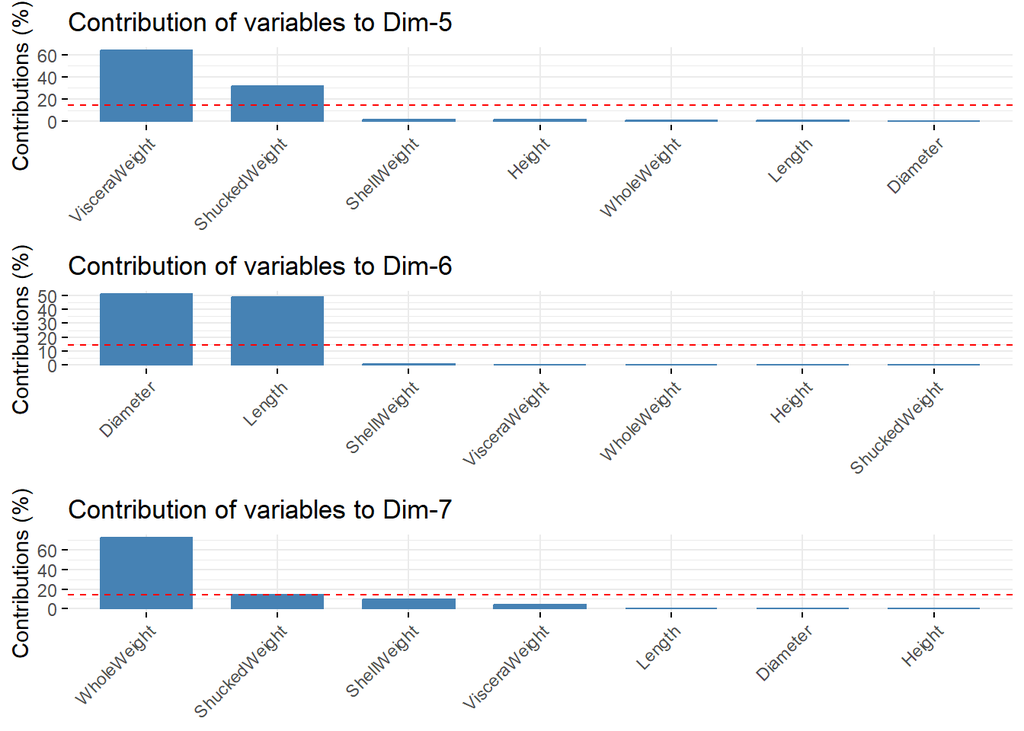

```r
grid.arrange(
fviz_contrib(abalonePCA, choice = "var", axes = 5),
fviz_contrib(abalonePCA, choice = "var", axes = 6),
fviz_contrib(abalonePCA, choice = "var", axes = 7))
```

Veiem que per dimensions més grans la contribució és mínima. Podem concloure que si ens quedéssim amb una columna (dimensió 1) podríem triar quasi qualsevol atribut ja que tots tenen una contribució molt semblant. En el cas de dues dimensions ens quedaríem amb Height i ShuckedWeight.

Contruim el model final de dades que ens servirà per fer l’estudi classificatori.

```r
abaloneFinal<-abaloneSet
```

Afagiré una columna per determinar si l’abalon és adult o no en funció del sexe.

```r
abaloneFinal$Adult <- ifelse(abaloneFinal$Sex == "I", 0, 1)
```

Finalment li afegiré els càlculs de abalonePCA amb dimensió 1 i 2 ja que eren els més rellevants.

```r
abaloneFinal$PCAD1 <- abalonePCA$ind$coord[, 1]
abaloneFinal$PCAD2 <- abalonePCA$ind$coord[, 2]
```

Consultem el Set dedades final:

```r
summary(abaloneFinal)
```

```
##      Sex                Length          Diameter          Height
##  Length:4173        Min.   :0.0750   Min.   :0.0550   Min.   :0.0000
##  Class :character   1st Qu.:0.4500   1st Qu.:0.3500   1st Qu.:0.1150
##  Mode  :character   Median :0.5450   Median :0.4250   Median :0.1400
##                     Mean   :0.5239   Mean   :0.4078   Mean   :0.1391
##                     3rd Qu.:0.6150   3rd Qu.:0.4800   3rd Qu.:0.1650
##                     Max.   :0.8150   Max.   :0.6500   Max.   :0.2500
##   WholeWeight     ShuckedWeight    VisceraWeight     ShellWeight
##  Min.   :0.0020   Min.   :0.0010   Min.   :0.0005   Min.   :0.0015
##  1st Qu.:0.4415   1st Qu.:0.1860   1st Qu.:0.0930   1st Qu.:0.1300
##  Median :0.7995   Median :0.3360   Median :0.1705   Median :0.2335
##  Mean   :0.8277   Mean   :0.3589   Mean   :0.1803   Mean   :0.2385
##  3rd Qu.:1.1530   3rd Qu.:0.5015   3rd Qu.:0.2525   3rd Qu.:0.3285
##  Max.   :2.8255   Max.   :1.4880   Max.   :0.6415   Max.   :0.8970
##      Rings            Adult            PCAD1             PCAD2
##  Min.   : 1.000   Min.   :0.0000   Min.   :-6.5397   Min.   :-2.39333
##  1st Qu.: 8.000   1st Qu.:0.0000   1st Qu.:-1.8637   1st Qu.:-0.21440
##  Median : 9.000   Median :1.0000   Median : 0.1003   Median : 0.06195
##  Mean   : 9.932   Mean   :0.6784   Mean   : 0.0000   Mean   : 0.00000
##  3rd Qu.:11.000   3rd Qu.:1.0000   3rd Qu.: 1.8134   3rd Qu.: 0.29571
##  Max.   :29.000   Max.   :1.0000   Max.   : 7.8007   Max.   : 1.79221
```

## 6.1 Exercici 1

### 6.1.1 Es genera un model no supervisat.

### 6.1.2 S’analitzen, mostren i comenten les mesures de qualitat del model generat.

### 6.1.3 S’interpreten els resultats i comenten les conclusions.

Usaré el model no supervisat k-means, que es basa en la distància de les dades per trobar grups representatius. Usem un dataset normalitzat:

```r
nor <- function(x) {(x-min(x))/(max(x)-min(x))}
abaloneFinalNor <-as.data.frame(lapply(abaloneFinal[2:12], nor))
```

Usarem un dataset per treballar amb el model no supervisat (nsp) k-means:

```r
abaloneFinalnsp <- abaloneFinalNor
```

```r
set.seed(666)
library(cluster)
d <- daisy(abaloneFinalnsp)
```

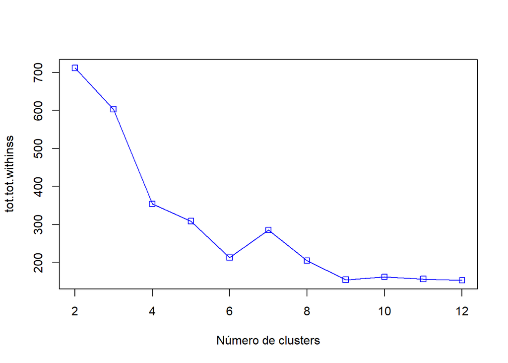

```r
result <- rep(0, 12)
for (i in c(2,3,4,5,6,7,8,9,10,11,12))
{
fit <- kmeans(abaloneFinalnsp, i)
result[i] <- fit$tot.withinss
}
plot(2:12,result[2:12],type="o",col="blue",pch=0,xlab="Número de clusters",ylab="tot.tot.withinss")
```

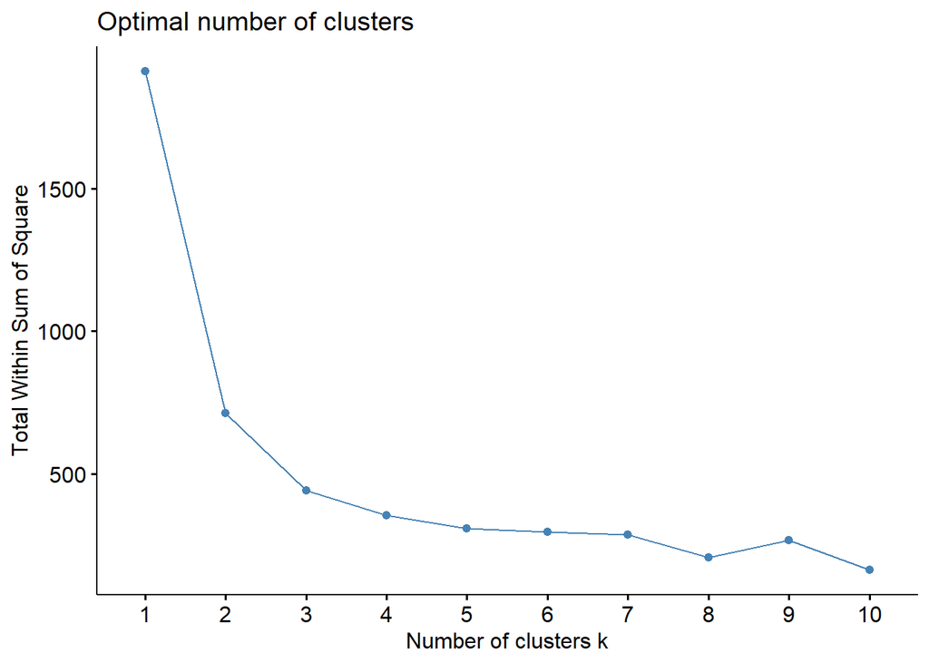

```r
fviz_nbclust(abaloneFinalnsp, kmeans, method = "wss")
```

La corba es comença a estavilitzae en el valor 3,això vol dir que segons k-mean hi ha 3 grups.

```r
set.seed(4)
abalone_clusters_3<- kmeans(abaloneFinalnsp, 3)
```

Observem la representació dels 3 clusters:

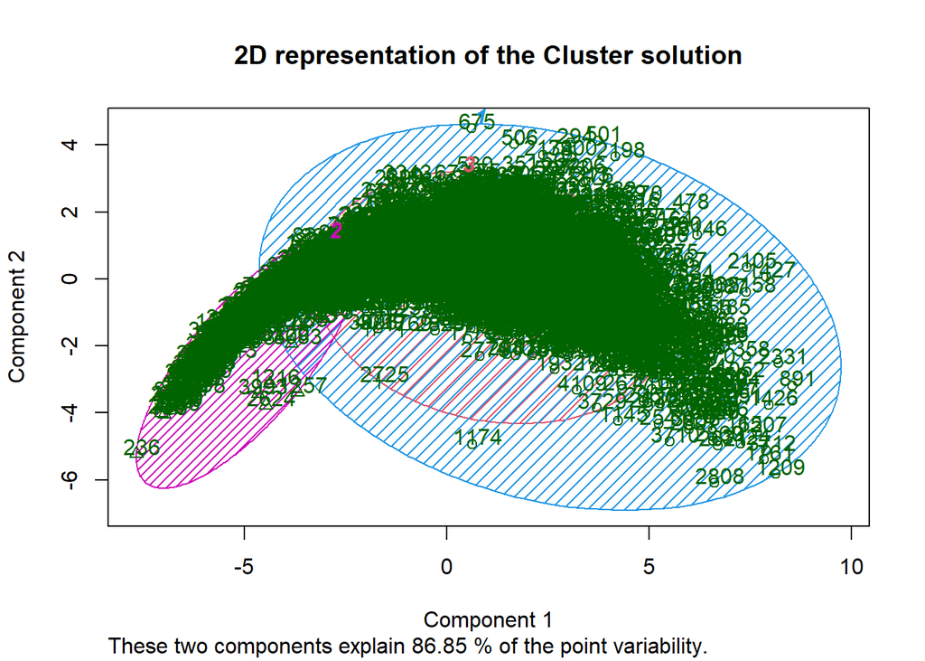

```r
clusplot(abaloneFinalnsp, abalone_clusters_3$cluster, main='2D representation of the Cluster solution',
color=TRUE, shade=TRUE,
labels=2, lines=0)
```

Height i ShuckedWeight són les columnes més representatives, anem a analitzar com ha quedat la divisió en comparació amb la realitat.

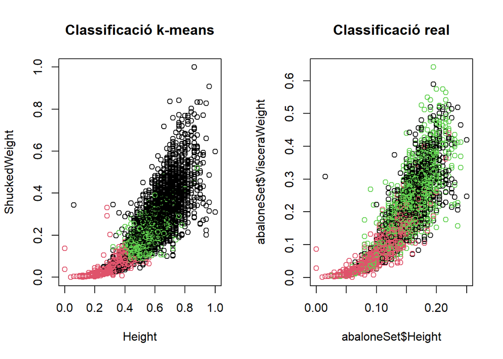

```r
r = c(1,2,3,4,5,6,7,8,9)
abaloneData<-abaloneSet %>% select(all_of(r))
old.par <- par(mfrow=c(1, 2))
plot(abaloneFinalnsp[c(3,5)], col=abalone_clusters_3$cluster, main="Classificació k-means")
plot(x = abaloneSet$Height, y = abaloneSet$VisceraWeight, col = as.factor(abaloneSet$Sex), main="Classificació real")
```

En la comparació podem veure com coincideix el grup Infantil però en el grup d’adults (M i F) d’ha detectat un grup però realment està molt dispers. Però per l’objectiu que ens concerneix sí funciona per detectar els infants dels adults.

Momstrem els diferents grups en taules:

```r
clustersTable=table(abalone_clusters_3$cluster)
clustersTable
```

```
##
##    1    2    3
## 2801  678  694
```

```r
abaloneSexTable=table(abaloneFinal$Sex)
abaloneSexTable
```

```
##
##    F    I    M
## 1305 1342 1526
```

Mostrem la taula de dispersió:

```r
abaloneSexTable=table(abalone_clusters_3$cluster, abaloneFinal$Sex)
abaloneSexTable
```

```
##
##        F    I    M
##   1 1303    0 1498
##   2    2  648   28
##   3    0  694    0
```

Veiem que en cluster 1 hi ha majoritàriament abaons adults femella i mascles, i en cluster 2 i 3 abalons infantils, i la precissió és bastant bona.

Calculem la precissió del model creat:

Casos correcte: 1303+1498+648+694= 4143

Casos incorrectes: 2+28= 30

Precissió: 4143/(4143+30)=0,9928->99%

Mirem si l’algorisme es porta igual amb diferents agrupacions, 2 per exemple per veure si identifica els adults dels infantils:

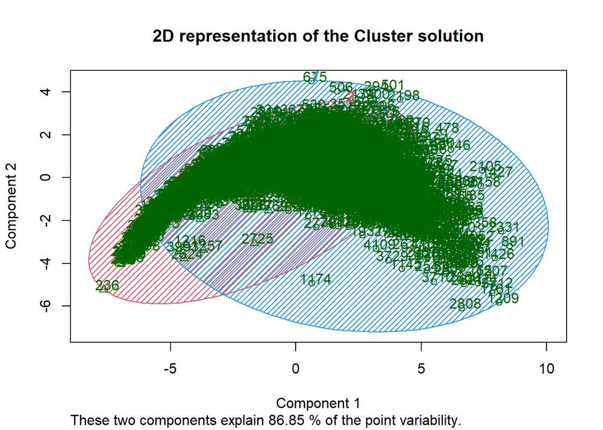

```r
set.seed(4)
abalone_clusters_2<- kmeans(abaloneFinalnsp, 2)
clusplot(abaloneFinalnsp, abalone_clusters_2$cluster, main='2D representation of the Cluster solution',
color=TRUE, shade=TRUE,
labels=2, lines=0)
```

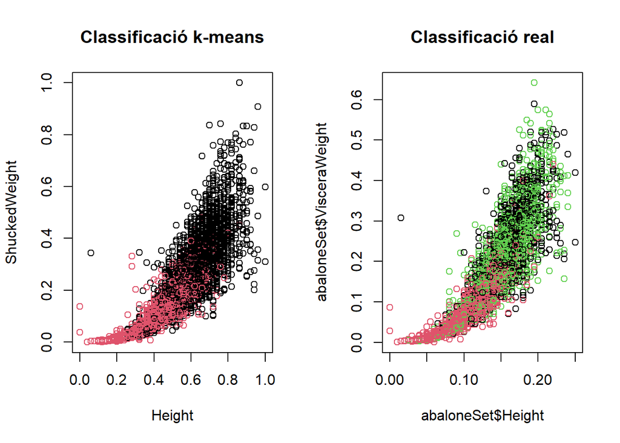

```r
old.par <- par(mfrow=c(1, 2))
plot(abaloneFinalnsp[c(3,5)], col=abalone_clusters_2$cluster, main="Classificació k-means")
plot(x = abaloneSet$Height, y = abaloneSet$VisceraWeight, col = as.factor(abaloneSet$Sex), main="Classificació real")
```

```r
clustersTable=table(abalone_clusters_2$cluster)
clustersTable
```

```
##
##    1    2
## 2825 1348
```

```r
abaloneSexTable=table(abaloneFinal$Sex)
abaloneSexTable
```

```
##
##    F    I    M
## 1305 1342 1526
```

```r
abaloneSexTable=table(abalone_clusters_2$cluster, abaloneFinal$Sex)
abaloneSexTable
```

```
##
##        F    I    M
##   1 1305    1 1519
##   2    0 1341    7
```

Calculem la precissió del model creat:

Casos correcte: 1305+1341+1519= 4165

Casos incorrectes: 1+7= 8

Precissió: 4165/(4165+8)=0,9981->99%

Veiem que aquest segn model és més precís a l’hora d’identificar els infants dels adults. Hem vist que en el model usant 3 models no es diferenciava correctament els mascles de les femelles, ja que els agrupav aen el mateix cluster i creava dos clusters pels joves, podríem dir que identificava els abalons nadons dels abalons a punt de fer-se adults.